# Confirmatory Factor Analyses

Sven Rieger

April 29, 2024

## Preface: Software

- The following packages are used:

```r
cfaPkg <- c("lavaan",
            "flextable")
```

- Install packages when not already installed:

```r
lapply(cfaPkg,
       function(x)
        if(!x %in% rownames(installed.packages())) {
          install.packages(x)
          }
      )
```

- Load (a subset of) the required package(s) into the `R` session.

```r
library(lavaan)
library(flextable)
```

## Preface: Data

To demonstrate, we use the first measurement time point of a simulated data set. The data simulation is described in the Example Data section. Alternatively, you can download the `wideLSdat.RDS` file here.

```r
wideLSdat <- readRDS("../example-data/wideLSdat.RDS")
```

## CFA: Introduction

> Confirmatory factor analysis” (CFA) is a type of structural equation modeling that deals specifically with measurement models, that is, the relationships between observed measures or “indicators” (e.g., items, test scores, behavioral observation ratings) and latent variables or “factors. (Brown & Moore, 2012, p. 361)

**Goal:** to establish the number and nature of factors (i.e., latent variables) that account for the variation and covariation among a set of indicators

- the indicators (i.e., observed measures) are intercorrelated because they share a common cause (or with other words: are influenced by the same underlying construct)

## Purposes of CFA

- Psychometric evaluation (e.g., Reliability; for scale reliability see here)
- Detection of method effects (e.g., covariation among indicators, after the latent variable was partialed out)
- Construct validation (e.g., convergent and discriminant validity); see also multi-trait-multi-method approaches (Campbell & Fiske, 1959)
- Evaluation of measurement invariance (see here)
- Scale development

## CFA parameters & graphical visualization

- Variance of the latent variable: $\Psi$
- Intercepts: $\nu$
- Factor loadings: $\lambda$
- Error variances: $\theta$

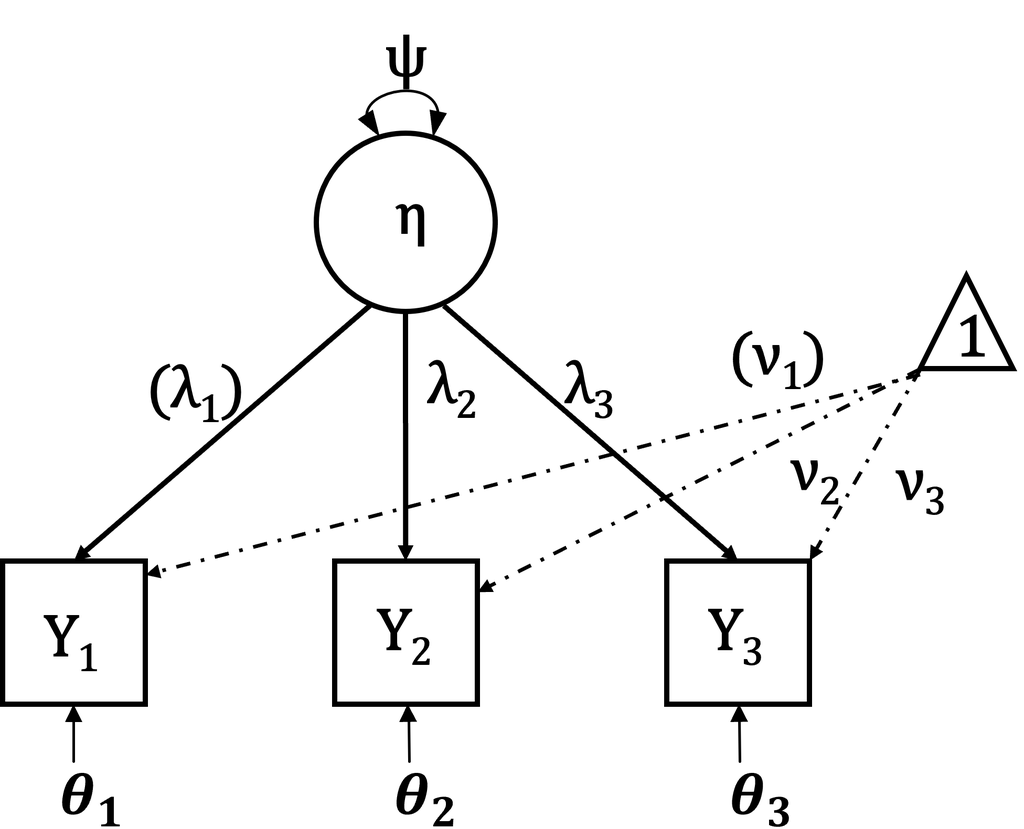

$$Y_i = \nu_i + \lambda_i\eta + \theta_i$$

$\Psi$: Psi

$\nu$: Nu

$\lambda$: Lambda

$\theta$: Theta

## Scale Reliability

- There is some debate about Cronbach’s Alpha Reliability Coefficient (Revelle & Zinbarg, 2009; Sijtsma, 2009)

> Even though the pages of [Psychometrika](https://www.springer.com/journal/11336) have been filled over the years with critiques and cautions about coefficient α and have seen elegant solutions for more appropriate estimates, few of these suggested coefficient are used.” (p.2)
- An alternative: Scale reliability
  - […] “reliability“ as the ratio of true variance to observed variance […]” (Raykov & Marcoulides, 2015)
- Scale reliability: $\rho = \frac{(\lambda_1+\dots+\lambda_k)^2}{(\lambda_1+\dots+\lambda_k)^2+\theta_1+\dots+\theta_k}$

see also McNeish (2017); Savalei & Reise (2019)

## Estimation of (CFA-) Model Parameters

- Model parameters are estimated on the basis of the empirical variances, covariances, and means
- This is done by minimizing the discrepancy between a sample variance-covariance matrix $S$ and a model-implied variance-covariance matrix $\Sigma(\theta)$
- Fit function for ML (without means):
  $$F_{ML}=log|\Sigma(\theta)|+tr(S\Sigma^{-1}(\theta))-log|S|-p$$
  - $\theta$ = Model parameters
  - $p$ = number of parameters of observed variables
  - $tr$ = trace (spur)

## Model identification I

**Going from the known to the unknown** (Kenny & Milan, 2012)

- Known information: number of elements in the variance-covariance matrix and the mean vector
  - In general with $k$ measured variables, there are…
    - k(k+1)/2 knowns (without meanstructure)
    - k(k+3)/2 knowns (with meanstructure)
- Unknown information: all parameters that need to be estimated
- Correspondence of known and unknown information determines whether a model is
  - underidentified
  - just-identified
  - overidentified

## Model identification II

**Goal of model testing:** Overidentification (i.e., Falsifiability; degree of wrongness → Fit indices)

## Model identification III

- Common SEM (!) situation
  - constructs have multiple indicators,
  - most indicators load only on one construct (i.e., “simple structure”),
  - each indicator has the same possible response scale (i.e., range)
- Little et al. (2006) describe 3 methods
  - Reference-Group Method: fixing the latent mean and the latent variance
  - Marker-Variable Method: fixing intercept to zero and loading of one indicator to 1
  - Effects-Coding Method: indicator intercepts sum to 0 the set of loadings sum to average 1

## Model identification IV

**Effects-Coding Method:** indicator intercepts sum to 0 the set of loadings sum to average 1

- loadings:
  $$\sum_{k=1}^{K} \lambda_{k} = K$$
- intercepts:
  $$\sum_{k=1}^{K} \tau_{k} = 0$$

```r
'
# a measurement model with 3 items
...
# constraints
lam1 == 3-lam2-lam3
nu1 == 0-nu2-nu3
'
```

## Model identification V

> This method uses the effects constraints to provide an optimal balance across the possible indicators to establish the scale for the estimated parameters, where the average intercept is zero, but no individual manifest intercept is fixed to be zero. Similarly, the loading parameters are estimated as an optimal balance around 1.0, but no individual loading is necessarily constrained to be 1.0. This method results in estimates of the latent variances that are the average of the indicators’ variances accounted for by the construct, and the latent means are estimated as optimally weighted averages of the set of indicator means for a given construct. In other words, the estimated latent variances and latent means reflect the observed metric of the indictors, optimally weighted by the degree to which each indicator represents the underlying latent construct. (Little et al., 2006, p. 63)

## Model evaluation

**Common fit indices (Hu & Bentler, 1998, 1999) are …**

for a critique see McNeish & Wolf (2021)

## Lavaan & Mplus syntax overview

| Formula type | Lavaan Operator | Mplus statement | Mnemonic |
| --- | --- | --- | --- |
| latent variable definition | `=~` | `by` | is measured by |
| regression | `~` | `on` | is regressed on |
| (residual) (co)variance | `~~` | `with` | is correlated with |
| intercept | `~ 1` | `[ ]` | intercept |
| – | `:=` | `=` | define functions |
| – | `==` | `==` | constraints |

lavaan syntax see [here](https://lavaan.ugent.be/tutorial/syntax1.html)

Mplus syntax see [here](https://www.statmodel.com/html_ug.shtml)

## CFA: lavaan implementation I

```r
CfaMod <- '
eta1 =~ lam1*Y11 + lam2*Y21 + lam3*Y31

Y11 ~ nu1*1
Y21 ~ nu2*1
Y31 ~ nu3*1

Y11 ~~ theta1*Y11
Y21 ~~ theta2*Y21
Y31 ~~ theta3*Y31

eta1 ~ 0*1
eta1 ~~ 1*eta1 #psi

rel := (lam1+lam2+lam3)^2 /
       ( (lam1+lam2+lam3)^2 +
         theta1+theta2+theta3 )
'
```

**1**

Use a string (i.e., `' '`) to specify the model; provide a recognizable and meanigful name (here: `CfaMod`)

**2**

Specifiy the measurement model using the *is measured by* operator: `=~`

**3**

(Optional) Specify the intercept of the item indicators using the intercept operatior: `~ 1`

**4**

(Optional) Specify the residual variances of the item indicators using the *is correlated with* operator: `~~`

**5**

(Optional) Specify the latent mean of the latent variable using the *intercept* operator: `~ 1`

**6**

(Optional) Specify the variance of the latent variable using the *is correlated with* operator: `~~`

**7**

(Optional) Use the model constraint option, to calculate the scale reliability (Raykov & Marcoulides, 2015)

## CFA: lavaan implementation II

```r
fitCfaMod <- sem(
    model = CfaMod,
    data = wideLSdat,
    estimator = "ML",
    std.lv = TRUE
    )
```

**1**

To fit the model, you may want to use the `sem` (or `cfa`) function

**2**

In the `model` argument, you need to provide the specified model as a string (here: `CfaMod`).

**3**

The dataset is provided in the `data` argument.

**4**

Choose an estimator (default for continuous variable is `ML`); in realworld scenarios you may want to choose a robust variant (e.g., `MLR`).

**5**

To fix the variance of the latent variabe to 1, we set the `std.lv` argument to `TRUE`.

## CFA: lavaan implementation III-I

```r
summary(
    fitCfaMod,
    fit = TRUE,
    standardized = TRUE,
    rsq = TRUE
    )
```

**1**

To retrieve the results via the `summary` function (display only), you need to provide the object of the fitted model (here: `fitCfaMod`)

**2**

The `fit` argument: Whether the typical fit indices should be printed.

**3**

The `standardized` argument: Whether standardized solutions should be printed.

**4**

The `rsq` argument: Whether $R^2$ should be printed.

The results are printed on the next slide.

## CFA: lavaan implementation III-II

```
lavaan 0.6.15 ended normally after 17 iterations

  Estimator                                         ML
  Optimization method                           NLMINB
  Number of model parameters                         9

  Number of observations                          1000

Model Test User Model:

  Test statistic                                 0.000
  Degrees of freedom                                 0

Model Test Baseline Model:

  Test statistic                               157.517
  Degrees of freedom                                 3
  P-value                                        0.000

User Model versus Baseline Model:

  Comparative Fit Index (CFI)                    1.000
  Tucker-Lewis Index (TLI)                       1.000

Loglikelihood and Information Criteria:

  Loglikelihood user model (H0)              -4604.807
  Loglikelihood unrestricted model (H1)      -4604.807

  Akaike (AIC)                                9227.615
  Bayesian (BIC)                              9271.785
  Sample-size adjusted Bayesian (SABIC)       9243.200

Root Mean Square Error of Approximation:

  RMSEA                                          0.000
  90 Percent confidence interval - lower         0.000
  90 Percent confidence interval - upper         0.000
  P-value H_0: RMSEA <= 0.050                       NA
  P-value H_0: RMSEA >= 0.080                       NA
```

[output cut: 26 more lines]

```
                   Estimate  Std.Err  z-value  P(>|z|)   Std.lv  Std.all
   .Y11     (tht1)    1.012    0.071   14.246    0.000    1.012    0.762
   .Y21     (tht2)    1.029    0.073   13.995    0.000    1.029    0.756
   .Y31     (tht3)    0.988    0.070   14.183    0.000    0.988    0.760
    eta1              1.000                               1.000    1.000

R-Square:
                   Estimate
    Y11               0.238
    Y21               0.244
    Y31               0.240

Defined Parameters:
                   Estimate  Std.Err  z-value  P(>|z|)   Std.lv  Std.all
    rel               0.487    0.028   17.345    0.000    0.487    0.487
```

## CFA: lavaan implementation IV

There are other ways to inspect or extract the results of the fitted model object

- Fit indices: `fitMeasures` function
- Parameter: `parameterEstimates` function
- Inspect/extraction function: `lavInspect`
  - `lavInspect(object, what = "coef")`
  - `lavInspect(object, what = "fit")`
  - `lavInspect(object, what = "sampstat")`
  - `lavInspect(object, what = "implied")`
  - …

## CFA: lavaan implementation: parameterEstimates

The `parameterEstimates` is designed to extract the estimated parameters of the model.

```r
cfaParm <- parameterEstimates(fitCfaMod,
                              se = TRUE,
                              zstat = TRUE,
                              pvalue = TRUE,
                              ci = TRUE,
                              standardized = FALSE,
                              rsquare = TRUE)
cfaParm[cfaParm$label == "rel","rhs"] <- "" # just cosmetic
cfaParm
```

```
    lhs op  rhs  label    est    se      z pvalue ci.lower ci.upper
1  eta1 =~  Y11   lam1  0.563 0.059  9.460  0.000    0.446    0.679
2  eta1 =~  Y21   lam2  0.576 0.061  9.500  0.000    0.457    0.694
3  eta1 =~  Y31   lam3  0.558 0.059  9.470  0.000    0.442    0.673
4   Y11 ~1         nu1 -0.048 0.036 -1.324  0.185   -0.120    0.023
5   Y21 ~1         nu2 -0.017 0.037 -0.461  0.644   -0.089    0.055
6   Y31 ~1         nu3 -0.011 0.036 -0.297  0.766   -0.081    0.060
7   Y11 ~~  Y11 theta1  1.012 0.071 14.246  0.000    0.873    1.152
8   Y21 ~~  Y21 theta2  1.029 0.073 13.995  0.000    0.884    1.173
9   Y31 ~~  Y31 theta3  0.988 0.070 14.183  0.000    0.851    1.124
10 eta1 ~1              0.000 0.000     NA     NA    0.000    0.000
11 eta1 ~~ eta1         1.000 0.000     NA     NA    1.000    1.000
12  rel :=         rel  0.487 0.028 17.345  0.000    0.432    0.542
13  Y11 r2  Y11         0.238    NA     NA     NA       NA       NA
14  Y21 r2  Y21         0.244    NA     NA     NA       NA       NA
15  Y31 r2  Y31         0.240    NA     NA     NA       NA       NA
```

## CFA: lavaan implementation V: Fit indices

The `fitMeasures` is designed to extract the fit indices of the model.

```r
cfaFit <- fitMeasures(fitCfaMod)
#names(cfaFit) get names
cfaFit[c("npar", "chisq", "df", "pvalue", "cfi", "rmsea")]
```

```
        npar        chisq           df       pvalue          cfi        rmsea
9.000000e+00 1.776357e-12 0.000000e+00           NA 1.000000e+00 0.000000e+00
```

## Make a CFA Table

```r
cfaResults <- cfaParm |>
  subset(select = c("label", "est", "se", "pvalue")) |>
  subset(subset = grepl("lam", label) |
                  grepl("rel", label)) |>
  within(label <- c(paste0("\\lambda_", 1:3),
                    "Rel.")) |>
  within(pvalue <- sprintf("%.3f", pvalue)) |>
  print()
```

```
        label   est    se pvalue
1  \\lambda_1 0.563 0.059  0.000
2  \\lambda_2 0.576 0.061  0.000
3  \\lambda_3 0.558 0.059  0.000
12       Rel. 0.487 0.028  0.000
```

```r
cfaFN <- paste0(c("CFI = ", "TLI = ", "RMSEA = ", "SRMR = "),
                  sprintf("%.3f",cfaFit[c("cfi", "tli", "rmsea", "srmr")]),
                  collapse = ", ")
cfaFN
```

```
[1] "CFI = 1.000, TLI = 1.000, RMSEA = 0.000, SRMR = 0.000"
```

## Print the CFA Table

```r
cfaResults |>
  flextable() |>
  theme_apa() |>
  set_header_labels(
    "label" = "Parameter",
    "est" = "Estimate",
    "se" = "SE",
    "pvalue" = "p") |>
  compose(j = "label", i = 1:3,
          value = as_paragraph((as_equation(label)))) |>
  add_footer_lines(
    as_paragraph(as_i("Note. "),
                 cfaFN)
      ) |>
  align(align = "left", part = "footer")
```

Table 1: Results of Confirmatory Factor Analyses

[output not shown]

Note. CFI = 1.000, TLI = 1.000, RMSEA = 0.000, SRMR = 0.000

```r
install.packages("equatags")
```

## References

Brown, T. A., & Moore, M. T. (2012). Confirmatory factor analysis. In R. H. Hoyle (Ed.), *Handbook of structural equation modeling*. Guilford Press.

Campbell, D. T., & Fiske, D. W. (1959). Convergent and discriminant validation by the multitrait-multimethod matrix. *Psychological Bulletin*, *56*(2), 81–105. https://doi.org/10.1037/h0046016

Hoyle, R. H. (Ed.). (2012). *Handbook of structural equation modeling*. Guilford Press.

Hu, L., & Bentler, P. M. (1998). Fit indices in covariance structure modeling: Sensitivity to underparameterized model misspecification. *Psychological Methods*, *3*(4), 424–453. https://doi.org/10.1037//1082-989X.3.4.424

Hu, L., & Bentler, P. M. (1999). Cutoff criteria for fit indexes in covariance structure analysis: Conventional criteria versus new alternatives. *Structural Equation Modeling: A Multidisciplinary Journal*, *6*(1), 1–55. https://doi.org/10.1080/10705519909540118

Kenny, D. A., & Milan, S. (2012). Identification: A non-technical discussion of a technical issue. In R. H. Hoyle (Ed.), *Handbook of structural equation modeling*. Guilford Press.

Little, T. D., Slegers, D. W., & Card, N. A. (2006). A non-arbitrary method of identifying and scaling latent bariables in SEM and MACS models. *Structural Equation Modeling: A Multidisciplinary Journal*, *13*(1), 59–72. https://doi.org/10.1207/s15328007sem1301‗ 3

McNeish, D. (2017). Thanks Coefficient Alpha, We’ll Take It From Here. *Psychological Methods*. https://doi.org/10.1037/met0000144

McNeish, D., & Wolf, M. G. (2021). Dynamic fit index cutoffs for confirmatory factor analysis models. *Psychological Methods*. https://doi.org/10.1037/met0000425

Raykov, T., & Marcoulides, G. A. (2015). Scale reliability evaluation under multiple assumption violations. *Structural Equation Modeling: A Multidisciplinary Journal*, *23*(2), 302–313. https://doi.org/10.1080/10705511.2014.938597

Revelle, W., & Zinbarg, R. E. (2009). Coefficients Alpha, Beta, Omega, and the glb: Comments on Sijtsma. *Psychometrika*, *74*(1), 145–154. https://doi.org/10.1007/s11336-008-9102-z

Savalei, V., & Reise, S. P. (2019). Don’t forget the model in your model-based reliability coefficients: A reply to McNeish (2018). *Collabra: Psychology*, *5*(1), 36. https://doi.org/10.1525/collabra.247

Sijtsma, K. (2009). On the Use, the Misuse, and the Very Limited Usefulness of Cronbach’s Alpha. *Psychometrika*, *74*(1), 107–120. https://doi.org/10.1007/s11336-008-9101-0